# Verbal autopsy data standardization

May 2017

## The goal

- Harness verbal autopsy data to better understand causes of mortality in one place at one time (make compatible with SmartVA).
- Make data compatible in one place *across* time.
- Make data compatible across *time* and *place*.

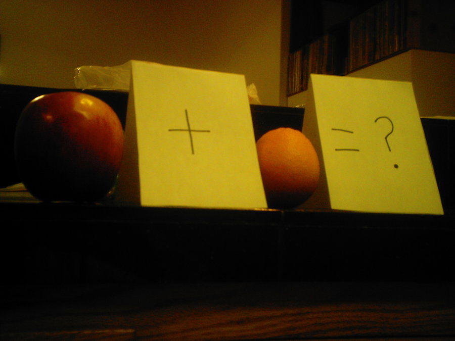

## The problem

## Data babel

[figure not shown]

## Data babel

### Diversity

- Diversity in content (the questions asked and answers collected)
- Diversity in form (the coding of those questions and answers)

### Why

- Many verbal autopsy datasets do not conform fully to the international standards of the time of creation
- Those very standards have changed over time

## VIDA

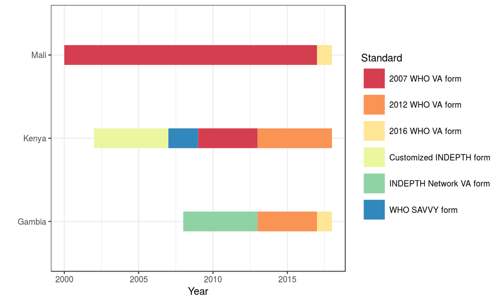

## The solution

## We can fix form, not content

### Content

We can't fix.

### Form

We can.

## The methods

## Two end languages

- Another standard (different variables and values, ie, "computer-speak")
- Meaningful phrases (questions and answers, ie "human-speak")

## Translation to another standard

- Generally, the purpose wil be to prepare data for SmartVA.
- Can also be used to combine datasets of different standards for ad-hoc analysis.

## Translation to meaningful phrases

- "child10019" becomes "What was the sex of the deceased?"
- 1 becomes "female"
- 2 becomes "male"

## Two kinds of translation

- The "clean" method
- The "fuzzy" method

## The clean method

- Translation is easiest when we are translating to a known standard (language) to another known standard.

## The clean method

- But this means explicitly engineering each standard (dictionary writing)

```
{"Symptoms1":"symptoms", "Q527A":"q148b", "Q601A_3":"q600x"}
```

- This is time-consuming and non-automatable

## The fuzzy method

- Employ approximate string matching to make a "best guess" at what each field is.
- Imperfect, but fast.
- Currently using Jaro-Winker distance.
- Employing user confirmation will allow us to train a machine learning model to improve the algorithm's performance.

## Next steps

## Long to-do list

- Recruit collaborators.
- Get more data examples.
- Get user input on concept and approach.
- Finish the hard-coding of dictionaries.
- Get user input on application interface.
- Devise user-data capture method for ML approach.

## The toolset

## 2 tools

### For expert users

A code base (R package; Python and others to come) for the “translation” of verbal autopsy data from one standard to another.

### For all users

An interactive web application for the translation of datasets from one standard to another (currently in Shiny/R; will port to Flask/Python depending on needs).

## Web application

[interactive chart not shown]

## Further information

## Resources

https://africanhealtheconomics.com  
https://joebrew.shinyapps.io/vida  
https://github.com/joebrew/vida

## Contact

Joe Brew  
joebrew@gmail.com  
Centro de Investigação em Saude de Manhiça (Mozambique) Institut de Salut Global de Barcelona (Spain)